# Exploring the health and economic impacts of storm events in NOAA Storm Database

E. Benzel

4/21/2020

## Loading and Processing the Data

The data for this assignment come in the form of a comma-separated-value file compressed via the bzip2 algorithm to reduce its size. You can download the file from the course web site: [Storm Data](https://d396qusza40orc.cloudfront.net/repdata%2Fdata%2FStormData.csv.bz2)

There is also some documentation of the database available. Here you will find how some of the variables are constructed/defined: [National Weather Service Storm Data Documentation](https://d396qusza40orc.cloudfront.net/repdata%2Fpeer2_doc%2Fpd01016005curr.pdf)

The events in the database start in the year 1950 and end in November 2011. In the earlier years of the database there are generally fewer events recorded, most likely due to a lack of good records. More recent years should be considered more complete.

```r
#load packages
library(tidyverse)
library(lubridate)
library(stringdist)
library(scales)
library(ggrepel)
```

```r
download.file("https://d396qusza40orc.cloudfront.net/repdata%2Fdata%2FStormData.csv.bz2","stormdata.csv.bz2")
storm.raw <- read_csv("stormdata.csv.bz2", col_types = cols(
    .default = col_double(),
    BGN_DATE = col_datetime(format = "%m/%d/%Y %H:%M:%S"),
    BGN_TIME = col_character(),
    TIME_ZONE = col_character(),
    COUNTYNAME = col_character(),
    STATE = col_character(),
    EVTYPE = col_character(),
    BGN_AZI = col_character(),
    BGN_LOCATI = col_character(),
    END_DATE = col_character(),
    END_TIME = col_character(),
    COUNTYENDN = col_character(),
    END_AZI = col_character(),
    END_LOCATI = col_character(),
    PROPDMGEXP = col_character(),
    CROPDMGEXP = col_character(),
    WFO = col_character(),
    STATEOFFIC = col_character(),
    ZONENAMES = col_character(),
    REMARKS = col_character()
))
```

First we can explore the general properties of the data set.

```r
dim(storm.raw)
```

```
## [1] 902297     37
```

Note there are 902297 observations of 37 variables. The variable of interest in both questions is EVTYPE which represents the type of storm event. Since according to [NOAA](https://www.ncdc.noaa.gov/stormevents/details.jsp?type=eventtype) all event types were gathered from 1996 onwards, only these years are subseted since both research questions regard comparsion between event types.

```r
storm.tmp <- storm.raw %>%
    filter(year(BGN_DATE) >= 1996)
```

### Processing event types

According to documentation linked above, there are 48 official event types: these events were copied into a .txt file and loaded into the data set.

```r
evtypes <- read_table("eventtypes.txt", col_names = "EVTYPE")
evtypes$EVTYPE <- tolower(evtypes$EVTYPE)
evtypes$EVTYPE <- str_replace(evtypes$EVTYPE, "/", " ")
evtypes
```

```
## # A tibble: 48 x 1
##    EVTYPE
##    <chr>
##  1 astronomical low tide
##  2 avalanche
##  3 blizzard
##  4 coastal flood
##  5 cold wind chill
##  6 debris flow
##  7 dense fog
##  8 dense smoke
##  9 drought
## 10 dust devil
## # ... with 38 more rows
```

```r
length(unique(storm.tmp$EVTYPE))
```

```
## [1] 508
```

Yet there are 508 unique values of the `EVTYPE` variable, so the code below cleans this variable.

First, high occurence abbreviations are replaced and slash charachers are removed.

```r
storm.tmp$EVTYPE <- storm.tmp$EVTYPE %>%
    tolower()  %>%
    str_replace("tstm", "thunderstorm") %>%
    str_replace("fld", "flood") %>%
    str_replace("/", " ")
```

Then, the function amatch from the package `stringdist` is used to match the variable `EVTYPE` to the set of official event types.

```r
storm.tmp$EVTYPEmatch <-
    evtypes$EVTYPE[amatch(x = storm.tmp$EVTYPE, table=evtypes$EVTYPE)]

mean(is.na(storm.tmp$EVTYPEmatch))
```

```
## [1] 0.02150781
```

Non matches (`NA`) represent 2.1% of the data set which might represent a significant contribution to harm. Therefore any instances of non matches are replaced with their original value.

```r
storm.tmp$EVTYPEmatch[is.na(storm.tmp$EVTYPEmatch)] <- storm.tmp$EVTYPE[is.na(storm.tmp$EVTYPEmatch)]
```

### Create data frame with variables of interest

For this analysis, we are going to analyze health and economic impact. Relevant health variables are `FATALITIES` and `INJURIES`. Relevant economic variables are `PROPDMG`, `PROPDMGEXP`, `CROPDMG`, and `CROPDMGEXP`.

### Processing

Since economic variables are split into two variables, these need to be combined according to the exponential code in `EXP`. [This](https://rstudio-pubs-static.s3.amazonaws.com/58957_37b6723ee52b455990e149edde45e5b6.html) article by Eddie Song referenced in the course forum was used to decode and process the two `EXP` variables.

```r
expprop <- read_delim("EXPcodes.txt", col_names = c("PROPDMGEXP", "PROPMULT"), delim = ",")
expcrop <- read_delim("EXPcodes.txt", col_names = c("CROPDMGEXP", "CROPMULT"), delim = ",")
expprop
```

```
## # A tibble: 20 x 2
##    PROPDMGEXP PROPMULT
##    <chr>      <chr>
##  1 H          " 100"
##  2 h          " 100"
##  3 K          " 1000"
##  4 k          " 1000"
##  5 M          " 1000000"
##  6 m          " 1000000"
##  7 B          " 1000000000"
##  8 b          " 1000000000"
##  9 0          " 10"
## 10 1          " 10"
## 11 2          " 10"
## 12 3          " 10"
## 13 4          " 10"
## 14 5          " 10"
## 15 6          " 10"
## 16 7          " 10"
## 17 8          " 10"
## 18 +          " 1"
## 19 -          " 0"
## 20 <NA>       " 1"
```

```r
storm.tmp2 <- storm.tmp %>%
    left_join(expprop) %>%
    left_join(expcrop) %>%
    filter(!is.na(PROPMULT)) %>% #NA EXP indicates 0 damage
    filter(!is.na(CROPMULT)) %>%
    filter(!is.na(CROPDMG)) %>%
    filter(!is.na(PROPDMG)) %>%
    mutate(propertyloss = as.numeric(PROPDMG)*as.numeric(PROPMULT)) %>%
    mutate(croploss = as.numeric(CROPDMG)*as.numeric(CROPMULT))
```

Finally, relevant variables are selected for analysis.

```r
storm.tmp2 <- mutate(storm.tmp2, year = year(BGN_DATE))

storm <- storm.tmp2 %>%
    select(event = EVTYPEmatch, fatalities = FATALITIES, injuries = INJURIES, propertyloss, croploss)

head(storm)
```

```
## # A tibble: 6 x 5
##   event             fatalities injuries propertyloss croploss
##   <chr>                  <dbl>    <dbl>        <dbl>    <dbl>
## 1 winter storm               0        0       380000    38000
## 2 tornado                    0        0       100000        0
## 3 thunderstorm wind          0        0         3000        0
## 4 thunderstorm wind          0        0         5000        0
## 5 thunderstorm wind          0        0         2000        0
## 6 hail                       0        0            0        0
```

Finally, the data is grouped by event type and the sum across all instances is found. The question could be interpreted in two ways: which type of events are individually more harmful or which type of events in aggregate are more harmful. This analysis seeks to answer the second question.

```r
storm.totals <- storm %>%
    count(event)

storm.byevent <- storm %>%
    group_by(event) %>%
    summarise_all(sum) %>%
    left_join(storm.totals)
```

## Results

### Which types of events are most harmful with respect to population health in the US?

As one can see from the summary charts below, there is a large range in the impact across event types with the majority of events types (at least 75%) having 0 fatalities or injuries.

```r
summary(select(storm.byevent, fatalities, injuries))
```

```
##    fatalities         injuries
##  Min.   :   0.00   Min.   :    0.0
##  1st Qu.:   0.00   1st Qu.:    0.0
##  Median :   0.00   Median :    0.0
##  Mean   :  20.55   Mean   :  136.4
##  3rd Qu.:   0.00   3rd Qu.:    0.0
##  Max.   :1797.00   Max.   :20667.0
```

The graph below shows the data grouped by event type and plotted showing the number of fatalities and injuries for each event with the size of each point showing the number of that event type that occured.

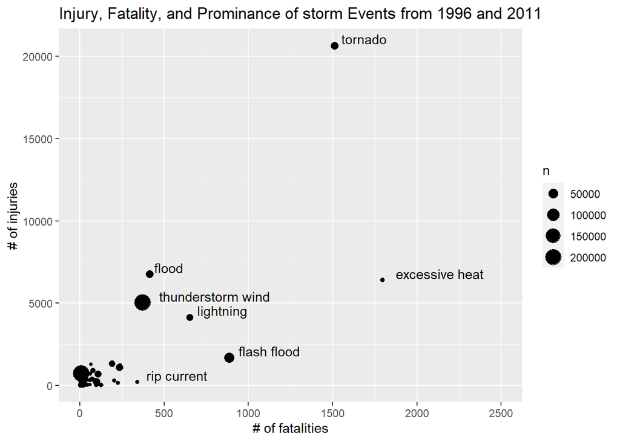

```r
storm.byevent %>%
    filter(fatalities > 0) %>%
    filter(injuries > 0) %>%

    ggplot(aes(x = fatalities, y = injuries)) +
    geom_point(aes(size = n)) +
    labs(x = "# of fatalities", y = "# of injuries") +
    coord_cartesian(xlim = c(0, 2500)) +
    geom_text(aes(label = ifelse(fatalities > 300,as.character(event),"")), hjust = -.15, vjust = -.15) +
    ggtitle("Injury, Fatality, and Prominance of storm Events from 1996 and 2011")
```

As you can see from the plot above, the labeled seven event types have a disproportionate impact on health related outcomes, specifically: tornado, excessive heat, flood, thunderstaorm wind, lightning, flash flood, and rip current Of these, excessive heat and tornado might be considered the most harmful both due to the high fatality and injury count but also due to their relatively small event count relative to the other most harmful events. One potential challenge to these results would be if the event types left unmatched in the data sorting did interesect to form significant contributions however due to the limited scope of this project, this possibility will remain a priority for future exploration.

### Which types of events have the greatest economic consequences in the US?

```r
summary(select(storm.byevent, propertyloss, croploss))
```

```
##   propertyloss          croploss
##  Min.   :0.000e+00   Min.   :0.000e+00
##  1st Qu.:0.000e+00   1st Qu.:0.000e+00
##  Median :0.000e+00   Median :0.000e+00
##  Mean   :8.630e+08   Mean   :8.177e+07
##  3rd Qu.:4.000e+04   3rd Qu.:0.000e+00
##  Max.   :1.439e+11   Max.   :1.337e+10
```

Similar to health related outcomes, the majority of event types had no economic impact however the maximum impacts are on the maginitude of billions of dollars. The events with the top 10 greatest economic impacts are examined below.

```r
 arrange(top_n(storm.byevent,10,propertyloss), desc(propertyloss))
```

```
## # A tibble: 10 x 6
##    event             fatalities injuries propertyloss   croploss      n
##    <chr>                  <dbl>    <dbl>        <dbl>      <dbl>  <int>
##  1 flood                    414     6758 143944833550 4974778400  24248
##  2 hurricane typhoon         64     1275  69305840000 2607872800     88
##  3 storm surge                2       37  43193536000       5000    253
##  4 tornado                 1511    20667  24616945710  283425010  23154
##  5 flash flood              887     1674  15222253910 1334901700  51000
##  6 hail                       7      713  14595143420 2476029450 207715
##  7 hurricane                 61       46  11812819010 2741410000    170
##  8 thunderstorm wind        371     5029   7868810880  952246350 210071
##  9 tropical storm            57      338   7642475550  677711000    682
## 10 high wind                235     1083   5247860360  633561300  19909
```

```r
 arrange(top_n(storm.byevent,10,croploss), desc(croploss))
```

```
## # A tibble: 10 x 6
##    event             fatalities injuries propertyloss    croploss      n
##    <chr>                  <dbl>    <dbl>        <dbl>       <dbl>  <int>
##  1 drought                    0        4   1046101000 13367566000   2433
##  2 flood                    414     6758 143944833550  4974778400  24248
##  3 hurricane                 61       46  11812819010  2741410000    170
##  4 hurricane typhoon         64     1275  69305840000  2607872800     88
##  5 hail                       7      713  14595143420  2476029450 207715
##  6 flash flood              887     1674  15222253910  1334901700  51000
##  7 extreme cold             115       79     19760400  1308973000    617
##  8 frost freeze               0        0     10480000  1094186000   1343
##  9 thunderstorm wind        371     5029   7868810880   952246350 210071
## 10 heavy rain                94      230    584864440   728169800  11528
```

Since economic impact to property is on the order of ten times the impact of crop damage, these two economic variables were combined to figure the overall total economic damage.

```r
storm.econ <- storm.byevent %>%
    mutate(econloss = propertyloss + croploss)
```

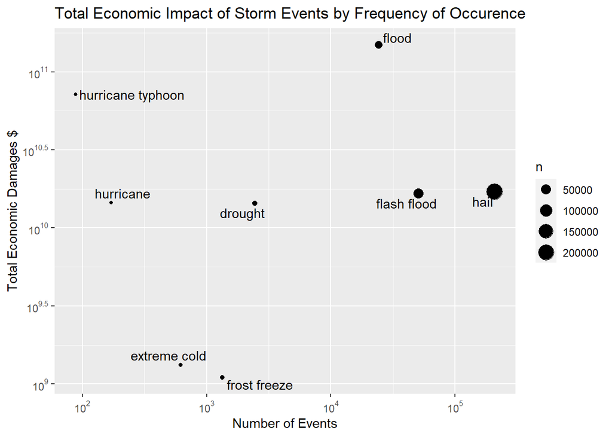

```r
storm.econ %>%
    filter(croploss > 10^9) %>%

    ggplot(aes(x = n, y = econloss, label = event)) +
    geom_point(aes(size = n)) +
    labs(x = "Number of Events", y = "Total Economic Damages $") +
    scale_x_log10(breaks = trans_breaks("log10", function(x) 10^x),
              labels = trans_format("log10", math_format(10^.x))) +
    scale_y_log10(breaks = trans_breaks("log10", function(x) 10^x),
              labels = trans_format("log10", math_format(10^.x))) +
    geom_text_repel() +
    ggtitle("Total Economic Impact of Storm Events by Frequency of Occurence")
```